# Untitled

2022-09-26

```r
library(haven)
library(tidyverse)
library(dplyr)
```

Read data

```r
data <- read_dta("Data/lhms1517a_r.dta")
data<-data[,c(1,2,303:526)]
```

Partnership History Q36

```r
data$LH36_A<-1
data$LH36_M<-if_else(is.na(data$LH36) | data$LH36==97,1,0)
```

Q36_1A

```r
data$LH36_1A_A<-if_else(data$LH36==1 | is.na(data$LH36),1,0)
data$LH36_1A_M<-if_else(is.na(data$LH36_1A) | data$LH36_1A==97,1,0)
```

Q36_1B

```r
data$LH36_1B_A<-if_else(data$LH36==1 | is.na(data$LH36),1,0)
data$LH36_1B_M<-if_else(is.na(data$LH36_1B) | data$LH36_1B==97,1,0)
```

Q36_1C

```r
data$LH36_1C_A<-if_else(data$LH36==1 | is.na(data$LH36),1,0)
data$LH36_1C_M<-if_else(is.na(data$LH36_1C) | data$LH36_1C==99997,1,0)
```

Q36_1D

```r
data$LH36_1D_A<-if_else(data$LH36==1 | is.na(data$LH36),1,0)
data$LH36_1D_M<-if_else(is.na(data$LH36_1D) | data$LH36_1D==97,1,0)
```

Q36_1E

```r
data$LH36_1E_A<-if_else(data$LH36==1 & data$LH36_1D!=1 | data$LH36==1 & is.na(data$LH36_1D) | is.na(data$LH36) & data$LH36_1D!=1 | is.na(data$LH36) & is.na(data$LH36_1D),1,0)
data$LH36_1E_M<-if_else(is.na(data$LH36_1E) | data$LH36_1E==99997,1,0)
```

Q36_2A

```r
data$LH36_2A_A<-if_else(data$LH36==5 | is.na(data$LH36_2A) & is.na(data$LH36_2B) & is.na(data$LH36_2C) & is.na(data$LH36_2D) & is.na(data$LH36_2E),0,1)
data$LH36_2A_M<-if_else(is.na(data$LH36_2A) | data$LH36_2A==97,1,0)
```

Q36_2B

```r
data$LH36_2B_A<-if_else(data$LH36==5 | is.na(data$LH36_2A) & is.na(data$LH36_2B) & is.na(data$LH36_2C) & is.na(data$LH36_2D) & is.na(data$LH36_2E),0,1)
data$LH36_2B_M<-if_else(is.na(data$LH36_2B) | data$LH36_2B==97,1,0)
```

Q36_2C

```r
data$LH36_2C_A<-if_else(data$LH36==5 | is.na(data$LH36_2A) & is.na(data$LH36_2B) & is.na(data$LH36_2C) & is.na(data$LH36_2D) & is.na(data$LH36_2E),0,1)
data$LH36_2C_M<-if_else(is.na(data$LH36_2C) | data$LH36_2C==99997,1,0)
```

Q36_2D

```r
data$LH36_2D_A<-if_else(data$LH36==5 | is.na(data$LH36_2A) & is.na(data$LH36_2B) & is.na(data$LH36_2C) & is.na(data$LH36_2D) & is.na(data$LH36_2E),0,1)
data$LH36_2D_M<-if_else(is.na(data$LH36_2D) | data$LH36_2D==97,1,0)
```

Q36_2E

```r
data$LH36_2E_A<-if_else(data$LH36==5 | is.na(data$LH36_2A) & is.na(data$LH36_2B) & is.na(data$LH36_2C) & data$LH36_2D==1 & is.na(data$LH36_2E) | is.na(data$LH36_2A) & is.na(data$LH36_2B) & is.na(data$LH36_2C) & is.na(data$LH36_2D) & is.na(data$LH36_2E),0,1)
data$LH36_2E_M<-if_else(is.na(data$LH36_2E) | data$LH36_2E==99997,1,0)
```

Q36_3A

```r
data$LH36_3A_A<-if_else(data$LH36==5 | is.na(data$LH36_3A) & is.na(data$LH36_3B) & is.na(data$LH36_3C) & is.na(data$LH36_3D) & is.na(data$LH36_3E),0,1)
data$LH36_3A_M<-if_else(is.na(data$LH36_3A) | data$LH36_3A==97,1,0)
```

Q36_3B

```r
data$LH36_3B_A<-if_else(data$LH36==5 | is.na(data$LH36_3A) & is.na(data$LH36_3B) & is.na(data$LH36_3C) & is.na(data$LH36_3D) & is.na(data$LH36_3E),0,1)
data$LH36_3B_M<-if_else(is.na(data$LH36_3B) | data$LH36_3B==97,1,0)
```

Q36_3C

```r
data$LH36_3C_A<-if_else(data$LH36==5 | is.na(data$LH36_3A) & is.na(data$LH36_3B) & is.na(data$LH36_3C) & is.na(data$LH36_3D) & is.na(data$LH36_3E),0,1)
data$LH36_3C_M<-if_else(is.na(data$LH36_3C) | data$LH36_3C==99997,1,0)
```

Q36_3D

```r
data$LH36_3D_A<-if_else(data$LH36==5 | is.na(data$LH36_3A) & is.na(data$LH36_3B) & is.na(data$LH36_3C) & is.na(data$LH36_3D) & is.na(data$LH36_3E),0,1)
data$LH36_3D_M<-if_else(is.na(data$LH36_3D) | data$LH36_3D==97,1,0)
```

Q36_3E

```r
data$LH36_3E_A<-if_else(data$LH36==5 | is.na(data$LH36_3A) & is.na(data$LH36_3B) & is.na(data$LH36_3C) & data$LH36_3D==1 & is.na(data$LH36_3E) | is.na(data$LH36_3A) & is.na(data$LH36_3B) & is.na(data$LH36_3C) & is.na(data$LH36_3D) & is.na(data$LH36_3E),0,1)
data$LH36_3E_M<-if_else(is.na(data$LH36_3E) | data$LH36_3E==99997,1,0)
```

Q36_4A

```r
data$LH36_4A_A<-if_else(data$LH36==5 | is.na(data$LH36_4A) & is.na(data$LH36_4B) & is.na(data$LH36_4C) & is.na(data$LH36_4D) & is.na(data$LH36_4E),0,1)
data$LH36_4A_M<-if_else(is.na(data$LH36_4A) | data$LH36_4A==97,1,0)
```

Q36_4B

```r
data$LH36_4B_A<-if_else(data$LH36==5 | is.na(data$LH36_4A) & is.na(data$LH36_4B) & is.na(data$LH36_4C) & is.na(data$LH36_4D) & is.na(data$LH36_4E),0,1)
data$LH36_4B_M<-if_else(is.na(data$LH36_4B) | data$LH36_4B==97,1,0)
```

Q36_4C

```r
data$LH36_4C_A<-if_else(data$LH36==5 | is.na(data$LH36_4A) & is.na(data$LH36_4B) & is.na(data$LH36_4C) & is.na(data$LH36_4D) & is.na(data$LH36_4E),0,1)
data$LH36_4C_M<-if_else(is.na(data$LH36_4C) | data$LH36_4C==99997,1,0)
```

Q36_4D

```r
data$LH36_4D_A<-if_else(data$LH36==5 | is.na(data$LH36_4A) & is.na(data$LH36_4B) & is.na(data$LH36_4C) & is.na(data$LH36_4D) & is.na(data$LH36_4E),0,1)
data$LH36_4D_M<-if_else(is.na(data$LH36_4D) | data$LH36_4D==97,1,0)
```

Q36_4E

```r
data$LH36_4E_A<-if_else(data$LH36==5 | is.na(data$LH36_4A) & is.na(data$LH36_4B) & is.na(data$LH36_4C) & data$LH36_4D==1 & is.na(data$LH36_4E) | is.na(data$LH36_4A) & is.na(data$LH36_4B) & is.na(data$LH36_4C) & is.na(data$LH36_4D) & is.na(data$LH36_4E),0,1)
data$LH36_4E_M<-if_else(is.na(data$LH36_4E) | data$LH36_4E==99997,1,0)
```

Q36_5A

```r
data$LH36_5A_A<-if_else(data$LH36==5 | is.na(data$LH36_5A) & is.na(data$LH36_5B) & is.na(data$LH36_5C) & is.na(data$LH36_5D) & is.na(data$LH36_5E),0,1)
data$LH36_5A_M<-if_else(is.na(data$LH36_5A) | data$LH36_5A==97,1,0)
```

Q36_5B

```r
data$LH36_5B_A<-if_else(data$LH36==5 | is.na(data$LH36_5A) & is.na(data$LH36_5B) & is.na(data$LH36_5C) & is.na(data$LH36_5D) & is.na(data$LH36_5E),0,1)
data$LH36_5B_M<-if_else(is.na(data$LH36_5B) | data$LH36_5B==97,1,0)
```

Q36_5C

```r
data$LH36_5C_A<-if_else(data$LH36==5 | is.na(data$LH36_5A) & is.na(data$LH36_5B) & is.na(data$LH36_5C) & is.na(data$LH36_5D) & is.na(data$LH36_5E),0,1)
data$LH36_5C_M<-if_else(is.na(data$LH36_5C) | data$LH36_5C==99997,1,0)
```

Q36_5D

```r
data$LH36_5D_A<-if_else(data$LH36==5 | is.na(data$LH36_5A) & is.na(data$LH36_5B) & is.na(data$LH36_5C) & is.na(data$LH36_5D) & is.na(data$LH36_5E),0,1)
data$LH36_5D_M<-if_else(is.na(data$LH36_5D) | data$LH36_5D==97,1,0)
```

Q36_5E

```r
data$LH36_5E_A<-if_else(data$LH36==5 | is.na(data$LH36_5A) & is.na(data$LH36_5B) & is.na(data$LH36_5C) & data$LH36_5D==1 & is.na(data$LH36_5E) | is.na(data$LH36_5A) & is.na(data$LH36_5B) & is.na(data$LH36_5C) & is.na(data$LH36_5D) & is.na(data$LH36_5E),0,1)
data$LH36_5E_M<-if_else(is.na(data$LH36_5E) | data$LH36_5E==99997,1,0)
```

Q37

```r
data$LH37_A<-1
data$LH37_M<-if_else(is.na(data$LH37) | data$LH37==97,1,0)
```

Q37_1A

```r
data$LH37_1A_A<-if_else(data$LH37==5 | is.na(data$LH37),0,1)
data$LH37_1A_M<-if_else(is.na(data$LH37_1A) | data$LH37_1A==97,1,0)
```

Q37_1B

```r
data$LH37_1B_A<-if_else(data$LH37==5 | is.na(data$LH37),0,1)
data$LH37_1B_M<-if_else(is.na(data$LH37_1B) | data$LH37_1B==99997,1,0)
```

Q37_1C

```r
data$LH37_1C_A<-if_else(data$LH37==5 | is.na(data$LH37),0,1)
data$LH37_1C_M<-if_else(is.na(data$LH37_1C) | data$LH37_1C==97,1,0)
```

Q37_1D

```r
data$LH37_1D_A<-if_else(data$LH37==5 & data$LH37_1C==3 | data$LH37==5 & is.na(data$LH37_1C) | is.na(data$LH37) & data$LH37_1C==3 | is.na(data$LH37) & is.na(data$LH37_1C),0,1)
data$LH37_1D_M<-if_else(is.na(data$LH37_1D) | data$LH37_1D==99997,1,0)
```

Q37_2A

```r
data$LH37_2A_A<-if_else(data$LH37==5 | is.na(data$LH37_2A) & is.na(data$LH37_2B) & is.na(data$LH37_2C) & is.na(data$LH37_2D),0,1)
data$LH37_2A_M<-if_else(is.na(data$LH37_2A) | data$LH37_2A==97,1,0)
```

Q37_2B

```r
data$LH37_2B_A<-if_else(data$LH37==5 | is.na(data$LH37_2A) & is.na(data$LH37_2B) & is.na(data$LH37_2C) & is.na(data$LH37_2D),0,1)
data$LH37_2B_M<-if_else(is.na(data$LH37_2B) | data$LH37_2B==99997,1,0)
```

Q37_2C

```r
data$LH37_2C_A<-if_else(data$LH37==5 | is.na(data$LH37_2A) & is.na(data$LH37_2B) & is.na(data$LH37_2C) & is.na(data$LH37_2D),0,1)
data$LH37_2C_M<-if_else(is.na(data$LH37_2C) | data$LH37_2C==97,1,0)
```

Q37_2D

```r
data$LH37_2D_A<-if_else(data$LH37==5 | is.na(data$LH37_2A) & is.na(data$LH37_2B) & data$LH37_2C==3 & is.na(data$LH37_2D) | is.na(data$LH37_2A) & is.na(data$LH37_2B) & is.na(data$LH37_2C) & is.na(data$LH37_2D),0,1)
data$LH37_2D_M<-if_else(is.na(data$LH37_2D) | data$LH37_2D==99997,1,0)
```

Q37_3A

```r
data$LH37_3A_A<-if_else(data$LH37==5 | is.na(data$LH37_3A) & is.na(data$LH37_3B) & is.na(data$LH37_3C) & is.na(data$LH37_3D),0,1)
data$LH37_3A_M<-if_else(is.na(data$LH37_3A) | data$LH37_3A==97,1,0)
```

Q37_3B

```r
data$LH37_3B_A<-if_else(data$LH37==5 | is.na(data$LH37_3A) & is.na(data$LH37_3B) & is.na(data$LH37_3C) & is.na(data$LH37_3D),0,1)
data$LH37_3B_M<-if_else(is.na(data$LH37_3B) | data$LH37_3B==99997,1,0)
```

Q37_3C

```r
data$LH37_3C_A<-if_else(data$LH37==5 | is.na(data$LH37_3A) & is.na(data$LH37_3B) & is.na(data$LH37_3C) & is.na(data$LH37_3D),0,1)
data$LH37_3C_M<-if_else(is.na(data$LH37_3C) | data$LH37_3C==97,1,0)
```

Q37_3D

```r
data$LH37_3D_A<-if_else(data$LH37==5 | is.na(data$LH37_3A) & is.na(data$LH37_3B) & data$LH37_3C==3 & is.na(data$LH37_3D) | is.na(data$LH37_3A) & is.na(data$LH37_3B) & is.na(data$LH37_3C) & is.na(data$LH37_3D),0,1)
data$LH37_3D_M<-if_else(is.na(data$LH37_3D) | data$LH37_3D==99997,1,0)
```

Q37_4A

```r
data$LH37_4A_A<-if_else(data$LH37==5 | is.na(data$LH37_4A) & is.na(data$LH37_4B) & is.na(data$LH37_4C) & is.na(data$LH37_4D),0,1)
data$LH37_4A_M<-if_else(is.na(data$LH37_4A) | data$LH37_4A==97,1,0)
```

Q37_4B

```r
data$LH37_4B_A<-if_else(data$LH37==5 | is.na(data$LH37_4A) & is.na(data$LH37_4B) & is.na(data$LH37_4C) & is.na(data$LH37_4D),0,1)
data$LH37_4B_M<-if_else(is.na(data$LH37_4B) | data$LH37_4B==99997,1,0)
```

Q37_4C

```r
data$LH37_4C_A<-if_else(data$LH37==5 | is.na(data$LH37_4A) & is.na(data$LH37_4B) & is.na(data$LH37_4C) & is.na(data$LH37_4D),0,1)
data$LH37_4C_M<-if_else(is.na(data$LH37_4C) | data$LH37_4C==97,1,0)
```

Q37_4D

```r
data$LH37_4D_A<-if_else(data$LH37==5 | is.na(data$LH37_4A) & is.na(data$LH37_4B) & data$LH37_4C==3 & is.na(data$LH37_4D) | is.na(data$LH37_4A) & is.na(data$LH37_4B) & is.na(data$LH37_4C) & is.na(data$LH37_4D),0,1)
data$LH37_4D_M<-if_else(is.na(data$LH37_4D) | data$LH37_4D==99997,1,0)
```

Q37_5A

```r
data$LH37_5A_A<-if_else(data$LH37==5 | is.na(data$LH37_5A) & is.na(data$LH37_5B) & is.na(data$LH37_5C) & is.na(data$LH37_5D),0,1)
data$LH37_5A_M<-if_else(is.na(data$LH37_5A) | data$LH37_5A==97,1,0)
```

Q37_5B

```r
data$LH37_5B_A<-if_else(data$LH37==5 | is.na(data$LH37_5A) & is.na(data$LH37_5B) & is.na(data$LH37_5C) & is.na(data$LH37_5D),0,1)
data$LH37_5B_M<-if_else(is.na(data$LH37_5B) | data$LH37_5B==99997,1,0)
```

Q37_5C

```r
data$LH37_5C_A<-if_else(data$LH37==5 | is.na(data$LH37_5A) & is.na(data$LH37_5B) & is.na(data$LH37_5C) & is.na(data$LH37_5D),0,1)
data$LH37_5C_M<-if_else(is.na(data$LH37_5C) | data$LH37_5C==97,1,0)
```

Q37_5D

```r
data$LH37_5D_A<-if_else(data$LH37==5 | is.na(data$LH37_5A) & is.na(data$LH37_5B) & data$LH37_5C==3 & is.na(data$LH37_5D) | is.na(data$LH37_5A) & is.na(data$LH37_5B) & is.na(data$LH37_5C) & is.na(data$LH37_5D),0,1)
data$LH37_5D_M<-if_else(is.na(data$LH37_5D) | data$LH37_5D==99997,1,0)
```

Your work History Q38

```r
data$LH38_A<-1
data$LH38_M<-if_else(is.na(data$LH38) | data$LH38==97,1,0)
```

Q38AM

```r
data$LH38AM_A<-if_else(data$LH38==1 | is.na(data$LH38),0,1)
data$LH38AM_M<-if_else(is.na(data$LH38AM1) | data$LH38AM1==97,1,0)
```

Q39A

```r
data$LH39A_A<-if_else(data$LH38==1 | is.na(data$LH38),1,0)
data$LH39A_M<-if_else(is.na(data$LH39A) | data$LH39A==97,1,0)
```

Q39B

```r
data$LH39B_A<-if_else(data$LH38==1 | is.na(data$LH38),1,0)
data$LH39B_M<-if_else(is.na(data$LH39B) | data$LH39B==97,1,0)
```

Q39C

```r
data$LH39C_A<-if_else(data$LH38==1 | is.na(data$LH38),1,0)
data$LH39C_M<-if_else(is.na(data$LH39C) | data$LH39C==97,1,0)
```

Q39D

```r
data$LH39D_A<-if_else(data$LH38==1 | is.na(data$LH38),1,0)
data$LH39D_M<-if_else(is.na(data$LH39D) | data$LH39D==97,1,0)
```

Q40A

```r
data$LH40A_A<-1
data$LH40A_M<-if_else(is.na(data$LH40A) | data$LH40A==97,1,0)
```

Q40B

```r
data$LH40B_A<-1
data$LH40B_M<-if_else(is.na(data$LH40B) | data$LH40B==97,1,0)
```

Q40C

```r
data$LH40C_A<-1
data$LH40C_M<-if_else(is.na(data$LH40C) | data$LH40C==97,1,0)
```

Q40D

```r
data$LH40D_A<-1
data$LH40D_M<-if_else(is.na(data$LH40D) | data$LH40D==97,1,0)
```

Q41_1A

```r
data$LH41_1A_A<-if_else(data$LH38==1 | is.na(data$LH38),1,0)
data$LH41_1A_M<-if_else(is.na(data$LH41_1A) | data$LH41_1A==99997,1,0)
```

Q41_1B

```r
data$LH41_1B_A<-if_else(data$LH38==1 | is.na(data$LH38),1,0)
data$LH41_1B_M<-if_else(is.na(data$LH41_1B) | data$LH41_1B==99997,1,0)
```

Q41_1C

```r
data$LH41_1C_A<-if_else(data$LH38==1 | is.na(data$LH38),1,0)
data$LH41_1C_M<-if_else(is.na(data$LH41_1C) | data$LH41_1C==97,1,0)
```

Q41_1DM

```r
data$LH41_1DM_A<-if_else(data$LH38==1 & data$LH41_1B<2018 | is.na(data$LH38) & data$LH41_1B<2018,1,0)
data$LH41_1DM_A[is.na(data$LH41_1DM_A)]<-0
data$LH41_1DM_M<-if_else(is.na(data$LH41_1DM1) | data$LH41_1DM1==997,1,0)
```

Q41_1EM

```r
data$LH41_1EM_A<-if_else(data$LH38==1 | is.na(data$LH38),1,0)
data$LH41_1EM_M<-if_else(is.na(data$LH41_1EM) | data$LH41_1EM==997,1,0)
```

Q41_1FM

```r
data$LH41_1FM_A<-if_else(data$LH38==1 | is.na(data$LH38),1,0)
data$LH41_1FM_M<-if_else(is.na(data$LH41_1FM) | data$LH41_1FM==997,1,0)
```

Q41_2A

```r
data$LH41_2A_A<-if_else(data$LH38==5 | is.na(data$LH41_2A) & is.na(data$LH41_2B) & is.na(data$LH41_2C) & is.na(data$LH41_2DM1) & is.na(data$LH41_2EM) & is.na(data$LH41_2FM),0,1)
data$LH41_2A_A[is.na(data$LH41_2A_A)]<-1
data$LH41_2A_M<-if_else(is.na(data$LH41_2A) | data$LH41_2A==99997,1,0)
```

Q41_2B

```r
data$LH41_2B_A<-if_else(data$LH38==5 | is.na(data$LH41_2A) & is.na(data$LH41_2B) & is.na(data$LH41_2C) & is.na(data$LH41_2DM1) & is.na(data$LH41_2EM) & is.na(data$LH41_2FM),0,1)
data$LH41_2B_A[is.na(data$LH41_2B_A)]<-1
data$LH41_2B_M<-if_else(is.na(data$LH41_2B) | data$LH41_2B==99997,1,0)
```

Q41_2C

```r
data$LH41_2C_A<-if_else(data$LH38==5 | is.na(data$LH41_2A) & is.na(data$LH41_2B) & is.na(data$LH41_2C) & is.na(data$LH41_2DM1) & is.na(data$LH41_2EM) & is.na(data$LH41_2FM),0,1)
data$LH41_2C_A[is.na(data$LH41_2C_A)]<-1
data$LH41_2C_M<-if_else(is.na(data$LH41_2C) | data$LH41_2C==97,1,0)
```

Q41_2DM

```r
data$LH41_2DM_A<-if_else(data$LH38==5 | is.na(data$LH41_2A) & is.na(data$LH41_2B) & is.na(data$LH41_2C) & is.na(data$LH41_2DM1) & is.na(data$LH41_2EM) & is.na(data$LH41_2FM),0,1)
data$LH41_2DM_A[is.na(data$LH41_2DM_A)]<-1
data$LH41_2DM_M<-if_else(is.na(data$LH41_2DM1) | data$LH41_2DM1==997,1,0)
```

Q41_2EM

```r
data$LH41_2EM_A<-if_else(data$LH38==5 | is.na(data$LH41_2A) & is.na(data$LH41_2B) & is.na(data$LH41_2C) & is.na(data$LH41_2DM1) & is.na(data$LH41_2EM) & is.na(data$LH41_2FM),0,1)
data$LH41_2EM_A[is.na(data$LH41_2EM_A)]<-1
data$LH41_2EM_M<-if_else(is.na(data$LH41_2EM) | data$LH41_2EM==997,1,0)
```

Q41_2FM

```r
data$LH41_2FM_A<-if_else(data$LH38==5 | is.na(data$LH41_2A) & is.na(data$LH41_2B) & is.na(data$LH41_2C) & is.na(data$LH41_2DM1) & is.na(data$LH41_2EM) & is.na(data$LH41_2FM),0,1)
data$LH41_2FM_A[is.na(data$LH41_2FM_A)]<-1
data$LH41_2FM_M<-if_else(is.na(data$LH41_2FM) | data$LH41_2FM==997,1,0)
```

Q41_3A

```r
data$LH41_3A_A<-if_else(data$LH38==5 | is.na(data$LH41_3A) & is.na(data$LH41_3B) & is.na(data$LH41_3C) & is.na(data$LH41_3DM1) & is.na(data$LH41_3EM) & is.na(data$LH41_3FM),0,1)
data$LH41_3A_A[is.na(data$LH41_3A_A)]<-1
data$LH41_3A_M<-if_else(is.na(data$LH41_3A) | data$LH41_3A==99997,1,0)
```

Q41_3B

```r
data$LH41_3B_A<-if_else(data$LH38==5 | is.na(data$LH41_3A) & is.na(data$LH41_3B) & is.na(data$LH41_3C) & is.na(data$LH41_3DM1) & is.na(data$LH41_3EM) & is.na(data$LH41_3FM),0,1)
data$LH41_3B_A[is.na(data$LH41_3B_A)]<-1
data$LH41_3B_M<-if_else(is.na(data$LH41_3B) | data$LH41_3B==99997,1,0)
```

Q41_3C

```r
data$LH41_3C_A<-if_else(data$LH38==5 | is.na(data$LH41_3A) & is.na(data$LH41_3B) & is.na(data$LH41_3C) & is.na(data$LH41_3DM1) & is.na(data$LH41_3EM) & is.na(data$LH41_3FM),0,1)
data$LH41_3C_A[is.na(data$LH41_3C_A)]<-1
data$LH41_3C_M<-if_else(is.na(data$LH41_3C) | data$LH41_3C==97,1,0)
```

Q41_3DM

```r
data$LH41_3DM_A<-if_else(data$LH38==5 | is.na(data$LH41_3A) & is.na(data$LH41_3B) & is.na(data$LH41_3C) & is.na(data$LH41_3DM1) & is.na(data$LH41_3EM) & is.na(data$LH41_3FM),0,1)
data$LH41_3DM_A[is.na(data$LH41_3DM_A)]<-1
data$LH41_3DM_M<-if_else(is.na(data$LH41_3DM1) | data$LH41_3DM1==997,1,0)
```

Q41_3EM

```r
data$LH41_3EM_A<-if_else(data$LH38==5 | is.na(data$LH41_3A) & is.na(data$LH41_3B) & is.na(data$LH41_3C) & is.na(data$LH41_3DM1) & is.na(data$LH41_3EM) & is.na(data$LH41_3FM),0,1)
data$LH41_3EM_A[is.na(data$LH41_3EM_A)]<-1
data$LH41_3EM_M<-if_else(is.na(data$LH41_3EM) | data$LH41_3EM==997,1,0)
```

Q41_3FM

```r
data$LH41_3FM_A<-if_else(data$LH38==5 | is.na(data$LH41_3A) & is.na(data$LH41_3B) & is.na(data$LH41_3C) & is.na(data$LH41_3DM1) & is.na(data$LH41_3EM) & is.na(data$LH41_3FM),0,1)
data$LH41_3FM_A[is.na(data$LH41_3FM_A)]<-1
data$LH41_3FM_M<-if_else(is.na(data$LH41_3FM) | data$LH41_3FM==997,1,0)
```

Q41_4A

```r
data$LH41_4A_A<-if_else(data$LH38==5 | is.na(data$LH41_4A) & is.na(data$LH41_4B) & is.na(data$LH41_4C) & is.na(data$LH41_4DM1) & is.na(data$LH41_4EM) & is.na(data$LH41_4FM),0,1)
data$LH41_4A_A[is.na(data$LH41_4A_A)]<-1
data$LH41_4A_M<-if_else(is.na(data$LH41_4A) | data$LH41_4A==99997,1,0)
```

Q41_4B

```r
data$LH41_4B_A<-if_else(data$LH38==5 | is.na(data$LH41_4A) & is.na(data$LH41_4B) & is.na(data$LH41_4C) & is.na(data$LH41_4DM1) & is.na(data$LH41_4EM) & is.na(data$LH41_4FM),0,1)
data$LH41_4B_A[is.na(data$LH41_4B_A)]<-1
data$LH41_4B_M<-if_else(is.na(data$LH41_4B) | data$LH41_4B==99997,1,0)
```

Q41_4C

```r
data$LH41_4C_A<-if_else(data$LH38==5 | is.na(data$LH41_4A) & is.na(data$LH41_4B) & is.na(data$LH41_4C) & is.na(data$LH41_4DM1) & is.na(data$LH41_4EM) & is.na(data$LH41_4FM),0,1)
data$LH41_4C_A[is.na(data$LH41_4C_A)]<-1
data$LH41_4C_M<-if_else(is.na(data$LH41_4C) | data$LH41_4C==97,1,0)
```

Q41_4DM

```r
data$LH41_4DM_A<-if_else(data$LH38==5 | is.na(data$LH41_4A) & is.na(data$LH41_4B) & is.na(data$LH41_4C) & is.na(data$LH41_4DM1) & is.na(data$LH41_4EM) & is.na(data$LH41_4FM),0,1)
data$LH41_4DM_A[is.na(data$LH41_4DM_A)]<-1
data$LH41_4DM_M<-if_else(is.na(data$LH41_4DM1) | data$LH41_4DM1==997,1,0)
```

Q41_4EM

```r
data$LH41_4EM_A<-if_else(data$LH38==5 | is.na(data$LH41_4A) & is.na(data$LH41_4B) & is.na(data$LH41_4C) & is.na(data$LH41_4DM1) & is.na(data$LH41_4EM) & is.na(data$LH41_4FM),0,1)
data$LH41_4EM_A[is.na(data$LH41_4EM_A)]<-1
data$LH41_4EM_M<-if_else(is.na(data$LH41_4EM) | data$LH41_4EM==997,1,0)
```

Q41_4FM

```r
data$LH41_4FM_A<-if_else(data$LH38==5 | is.na(data$LH41_4A) & is.na(data$LH41_4B) & is.na(data$LH41_4C) & is.na(data$LH41_4DM1) & is.na(data$LH41_4EM) & is.na(data$LH41_4FM),0,1)
data$LH41_4FM_A[is.na(data$LH41_4FM_A)]<-1
data$LH41_4FM_M<-if_else(is.na(data$LH41_4FM) | data$LH41_4FM==997,1,0)
```

Q41_5A

```r
data$LH41_5A_A<-if_else(data$LH38==5 | is.na(data$LH41_5A) & is.na(data$LH41_5B) & is.na(data$LH41_5C) & is.na(data$LH41_5DM1) & is.na(data$LH41_5EM) & is.na(data$LH41_5FM),0,1)
data$LH41_5A_A[is.na(data$LH41_5A_A)]<-1
data$LH41_5A_M<-if_else(is.na(data$LH41_5A) | data$LH41_5A==99997,1,0)
```

Q41_5B

```r
data$LH41_5B_A<-if_else(data$LH38==5 | is.na(data$LH41_5A) & is.na(data$LH41_5B) & is.na(data$LH41_5C) & is.na(data$LH41_5DM1) & is.na(data$LH41_5EM) & is.na(data$LH41_5FM),0,1)
data$LH41_5B_A[is.na(data$LH41_5B_A)]<-1
data$LH41_5B_M<-if_else(is.na(data$LH41_5B) | data$LH41_5B==99997,1,0)
```

Q41_5C

```r
data$LH41_5C_A<-if_else(data$LH38==5 | is.na(data$LH41_5A) & is.na(data$LH41_5B) & is.na(data$LH41_5C) & is.na(data$LH41_5DM1) & is.na(data$LH41_5EM) & is.na(data$LH41_5FM),0,1)
data$LH41_5C_A[is.na(data$LH41_5C_A)]<-1
data$LH41_5C_M<-if_else(is.na(data$LH41_5C) | data$LH41_5C==97,1,0)
```

Q41_5DM

```r
data$LH41_5DM_A<-if_else(data$LH38==5 | is.na(data$LH41_5A) & is.na(data$LH41_5B) & is.na(data$LH41_5C) & is.na(data$LH41_5DM1) & is.na(data$LH41_5EM) & is.na(data$LH41_5FM),0,1)
data$LH41_5DM_A[is.na(data$LH41_5DM_A)]<-1
data$LH41_5DM_M<-if_else(is.na(data$LH41_5DM1) | data$LH41_5DM1==997,1,0)
```

Q41_5EM

```r
data$LH41_5EM_A<-if_else(data$LH38==5 | is.na(data$LH41_5A) & is.na(data$LH41_5B) & is.na(data$LH41_5C) & is.na(data$LH41_5DM1) & is.na(data$LH41_5EM) & is.na(data$LH41_5FM),0,1)
data$LH41_5EM_A[is.na(data$LH41_5EM_A)]<-1
data$LH41_5EM_M<-if_else(is.na(data$LH41_5EM) | data$LH41_5EM==997,1,0)
```

Q41_5FM

```r
data$LH41_5FM_A<-if_else(data$LH38==5 | is.na(data$LH41_5A) & is.na(data$LH41_5B) & is.na(data$LH41_5C) & is.na(data$LH41_5DM1) & is.na(data$LH41_5EM) & is.na(data$LH41_5FM),0,1)
data$LH41_5FM_A[is.na(data$LH41_5FM_A)]<-1
data$LH41_5FM_M<-if_else(is.na(data$LH41_5FM) | data$LH41_5FM==997,1,0)
```

Q41_6A

```r
data$LH41_6A_A<-if_else(data$LH38==5 | is.na(data$LH41_6A) & is.na(data$LH41_6B) & is.na(data$LH41_6C) & is.na(data$LH41_6DM1) & is.na(data$LH41_6EM) & is.na(data$LH41_6FM),0,1)
data$LH41_6A_A[is.na(data$LH41_6A_A)]<-1
data$LH41_6A_M<-if_else(is.na(data$LH41_6A) | data$LH41_6A==99997,1,0)
```

Q41_6B

```r
data$LH41_6B_A<-if_else(data$LH38==5 | is.na(data$LH41_6A) & is.na(data$LH41_6B) & is.na(data$LH41_6C) & is.na(data$LH41_6DM1) & is.na(data$LH41_6EM) & is.na(data$LH41_6FM),0,1)
data$LH41_6B_A[is.na(data$LH41_6B_A)]<-1
data$LH41_6B_M<-if_else(is.na(data$LH41_6B) | data$LH41_6B==99997,1,0)
```

Q41_6C

```r
data$LH41_6C_A<-if_else(data$LH38==5 | is.na(data$LH41_6A) & is.na(data$LH41_6B) & is.na(data$LH41_6C) & is.na(data$LH41_6DM1) & is.na(data$LH41_6EM) & is.na(data$LH41_6FM),0,1)
data$LH41_6C_A[is.na(data$LH41_6C_A)]<-1
data$LH41_6C_M<-if_else(is.na(data$LH41_6C) | data$LH41_6C==97,1,0)
```

Q41_6DM

```r
data$LH41_6DM_A<-if_else(data$LH38==5 | is.na(data$LH41_6A) & is.na(data$LH41_6B) & is.na(data$LH41_6C) & is.na(data$LH41_6DM1) & is.na(data$LH41_6EM) & is.na(data$LH41_6FM),0,1)
data$LH41_6DM_A[is.na(data$LH41_6DM_A)]<-1
data$LH41_6DM_M<-if_else(is.na(data$LH41_6DM1) | data$LH41_6DM1==997,1,0)
```

Q41_6EM

```r
data$LH41_6EM_A<-if_else(data$LH38==5 | is.na(data$LH41_6A) & is.na(data$LH41_6B) & is.na(data$LH41_6C) & is.na(data$LH41_6DM1) & is.na(data$LH41_6EM) & is.na(data$LH41_6FM),0,1)
data$LH41_6EM_A[is.na(data$LH41_6EM_A)]<-1
data$LH41_6EM_M<-if_else(is.na(data$LH41_6EM) | data$LH41_6EM==997,1,0)
```

Q41_6FM

```r
data$LH41_6FM_A<-if_else(data$LH38==5 | is.na(data$LH41_6A) & is.na(data$LH41_6B) & is.na(data$LH41_6C) & is.na(data$LH41_6DM1) & is.na(data$LH41_6EM) & is.na(data$LH41_6FM),0,1)
data$LH41_6FM_A[is.na(data$LH41_6FM_A)]<-1
data$LH41_6FM_M<-if_else(is.na(data$LH41_6FM) | data$LH41_6FM==997,1,0)
```

Q41_7A

```r
data$LH41_7A_A<-if_else(data$LH38==5 | is.na(data$LH41_7A) & is.na(data$LH41_7B) & is.na(data$LH41_7C) & is.na(data$LH41_7DM1) & is.na(data$LH41_7EM) & is.na(data$LH41_7FM),0,1)
data$LH41_7A_A[is.na(data$LH41_7A_A)]<-1
data$LH41_7A_M<-if_else(is.na(data$LH41_7A) | data$LH41_7A==99997,1,0)
```

Q41_7B

```r
data$LH41_7B_A<-if_else(data$LH38==5 | is.na(data$LH41_7A) & is.na(data$LH41_7B) & is.na(data$LH41_7C) & is.na(data$LH41_7DM1) & is.na(data$LH41_7EM) & is.na(data$LH41_7FM),0,1)
data$LH41_7B_A[is.na(data$LH41_7B_A)]<-1
data$LH41_7B_M<-if_else(is.na(data$LH41_7B) | data$LH41_7B==99997,1,0)
```

Q41_7C

```r
data$LH41_7C_A<-if_else(data$LH38==5 | is.na(data$LH41_7A) & is.na(data$LH41_7B) & is.na(data$LH41_7C) & is.na(data$LH41_7DM1) & is.na(data$LH41_7EM) & is.na(data$LH41_7FM),0,1)
data$LH41_7C_A[is.na(data$LH41_7C_A)]<-1
data$LH41_7C_M<-if_else(is.na(data$LH41_7C) | data$LH41_7C==97,1,0)
```

Q41_7DM

```r
data$LH41_7DM_A<-if_else(data$LH38==5 | is.na(data$LH41_7A) & is.na(data$LH41_7B) & is.na(data$LH41_7C) & is.na(data$LH41_7DM1) & is.na(data$LH41_7EM) & is.na(data$LH41_7FM),0,1)
data$LH41_7DM_A[is.na(data$LH41_7DM_A)]<-1
data$LH41_7DM_M<-if_else(is.na(data$LH41_7DM1) | data$LH41_7DM1==997,1,0)
```

Q41_7EM

```r
data$LH41_7EM_A<-if_else(data$LH38==5 | is.na(data$LH41_7A) & is.na(data$LH41_7B) & is.na(data$LH41_7C) & is.na(data$LH41_7DM1) & is.na(data$LH41_7EM) & is.na(data$LH41_7FM),0,1)
data$LH41_7EM_A[is.na(data$LH41_7EM_A)]<-1
data$LH41_7EM_M<-if_else(is.na(data$LH41_7EM) | data$LH41_7EM==997,1,0)
```

Q41_7FM

```r
data$LH41_7FM_A<-if_else(data$LH38==5 | is.na(data$LH41_7A) & is.na(data$LH41_7B) & is.na(data$LH41_7C) & is.na(data$LH41_7DM1) & is.na(data$LH41_7EM) & is.na(data$LH41_7FM),0,1)
data$LH41_7FM_A[is.na(data$LH41_7FM_A)]<-1
data$LH41_7FM_M<-if_else(is.na(data$LH41_7FM) | data$LH41_7FM==997,1,0)
```

Q41_8A

```r
data$LH41_8A_A<-if_else(data$LH38==5 | is.na(data$LH41_8A) & is.na(data$LH41_8B) & is.na(data$LH41_8C) & is.na(data$LH41_8DM1) & is.na(data$LH41_8EM) & is.na(data$LH41_8FM),0,1)
data$LH41_8A_A[is.na(data$LH41_8A_A)]<-1
data$LH41_8A_M<-if_else(is.na(data$LH41_8A) | data$LH41_8A==99997,1,0)
```

Q41_8B

```r
data$LH41_8B_A<-if_else(data$LH38==5 | is.na(data$LH41_8A) & is.na(data$LH41_8B) & is.na(data$LH41_8C) & is.na(data$LH41_8DM1) & is.na(data$LH41_8EM) & is.na(data$LH41_8FM),0,1)
data$LH41_8B_A[is.na(data$LH41_8B_A)]<-1
data$LH41_8B_M<-if_else(is.na(data$LH41_8B) | data$LH41_8B==99997,1,0)
```

Q41_8C

```r
data$LH41_8C_A<-if_else(data$LH38==5 | is.na(data$LH41_8A) & is.na(data$LH41_8B) & is.na(data$LH41_8C) & is.na(data$LH41_8DM1) & is.na(data$LH41_8EM) & is.na(data$LH41_8FM),0,1)
data$LH41_8C_A[is.na(data$LH41_8C_A)]<-1
data$LH41_8C_M<-if_else(is.na(data$LH41_8C) | data$LH41_8C==97,1,0)
```

Q41_8DM

```r
data$LH41_8DM_A<-if_else(data$LH38==5 | is.na(data$LH41_8A) & is.na(data$LH41_8B) & is.na(data$LH41_8C) & is.na(data$LH41_8DM1) & is.na(data$LH41_8EM) & is.na(data$LH41_8FM),0,1)
data$LH41_8DM_A[is.na(data$LH41_8DM_A)]<-1
data$LH41_8DM_M<-if_else(is.na(data$LH41_8DM1) | data$LH41_8DM1==997,1,0)
```

Q41_8EM

```r
data$LH41_8EM_A<-if_else(data$LH38==5 | is.na(data$LH41_8A) & is.na(data$LH41_8B) & is.na(data$LH41_8C) & is.na(data$LH41_8DM1) & is.na(data$LH41_8EM) & is.na(data$LH41_8FM),0,1)
data$LH41_8EM_A[is.na(data$LH41_8EM_A)]<-1
data$LH41_8EM_M<-if_else(is.na(data$LH41_8EM) | data$LH41_8EM==997,1,0)
```

Q41_8FM

```r
data$LH41_8FM_A<-if_else(data$LH38==5 | is.na(data$LH41_8A) & is.na(data$LH41_8B) & is.na(data$LH41_8C) & is.na(data$LH41_8DM1) & is.na(data$LH41_8EM) & is.na(data$LH41_8FM),0,1)
data$LH41_8FM_A[is.na(data$LH41_8FM_A)]<-1
data$LH41_8FM_M<-if_else(is.na(data$LH41_8FM) | data$LH41_8FM==997,1,0)
```

Q41_9A

```r
data$LH41_9A_A<-if_else(data$LH38==5 | is.na(data$LH41_9A) & is.na(data$LH41_9B) & is.na(data$LH41_9C) & is.na(data$LH41_9DM1) & is.na(data$LH41_9EM) & is.na(data$LH41_9FM),0,1)
data$LH41_9A_A[is.na(data$LH41_9A_A)]<-1
data$LH41_9A_M<-if_else(is.na(data$LH41_9A) | data$LH41_9A==99997,1,0)
```

Q41_9B

```r
data$LH41_9B_A<-if_else(data$LH38==5 | is.na(data$LH41_9A) & is.na(data$LH41_9B) & is.na(data$LH41_9C) & is.na(data$LH41_9DM1) & is.na(data$LH41_9EM) & is.na(data$LH41_9FM),0,1)
data$LH41_9B_A[is.na(data$LH41_9B_A)]<-1
data$LH41_9B_M<-if_else(is.na(data$LH41_9B) | data$LH41_9B==99997,1,0)
```

Q41_9C

```r
data$LH41_9C_A<-if_else(data$LH38==5 | is.na(data$LH41_9A) & is.na(data$LH41_9B) & is.na(data$LH41_9C) & is.na(data$LH41_9DM1) & is.na(data$LH41_9EM) & is.na(data$LH41_9FM),0,1)
data$LH41_9C_A[is.na(data$LH41_9C_A)]<-1
data$LH41_9C_M<-if_else(is.na(data$LH41_9C) | data$LH41_9C==97,1,0)
```

Q41_9DM

```r
data$LH41_9DM_A<-if_else(data$LH38==5 | is.na(data$LH41_9A) & is.na(data$LH41_9B) & is.na(data$LH41_9C) & is.na(data$LH41_9DM1) & is.na(data$LH41_9EM) & is.na(data$LH41_9FM),0,1)
data$LH41_9DM_A[is.na(data$LH41_9DM_A)]<-1
data$LH41_9DM_M<-if_else(is.na(data$LH41_9DM1) | data$LH41_9DM1==997,1,0)
```

Q41_9EM

```r
data$LH41_9EM_A<-if_else(data$LH38==5 | is.na(data$LH41_9A) & is.na(data$LH41_9B) & is.na(data$LH41_9C) & is.na(data$LH41_9DM1) & is.na(data$LH41_9EM) & is.na(data$LH41_9FM),0,1)
data$LH41_9EM_A[is.na(data$LH41_9EM_A)]<-1
data$LH41_9EM_M<-if_else(is.na(data$LH41_9EM) | data$LH41_9EM==997,1,0)
```

Q41_9FM

```r
data$LH41_9FM_A<-if_else(data$LH38==5 | is.na(data$LH41_9A) & is.na(data$LH41_9B) & is.na(data$LH41_9C) & is.na(data$LH41_9DM1) & is.na(data$LH41_9EM) & is.na(data$LH41_9FM),0,1)
data$LH41_9FM_A[is.na(data$LH41_9FM_A)]<-1
data$LH41_9FM_M<-if_else(is.na(data$LH41_9FM) | data$LH41_9FM==997,1,0)
```

Q41_10A

```r
data$LH41_10A_A<-if_else(data$LH38==5 | is.na(data$LH41_10A) & is.na(data$LH41_10B) & is.na(data$LH41_10C) & is.na(data$LH41_10DM1) & is.na(data$LH41_10EM) & is.na(data$LH41_10FM),0,1)
data$LH41_10A_A[is.na(data$LH41_10A_A)]<-1
data$LH41_10A_M<-if_else(is.na(data$LH41_10A) | data$LH41_10A==99997,1,0)
```

Q41_10B

```r
data$LH41_10B_A<-if_else(data$LH38==5 | is.na(data$LH41_10A) & is.na(data$LH41_10B) & is.na(data$LH41_10C) & is.na(data$LH41_10DM1) & is.na(data$LH41_10EM) & is.na(data$LH41_10FM),0,1)
data$LH41_10B_A[is.na(data$LH41_10B_A)]<-1
data$LH41_10B_M<-if_else(is.na(data$LH41_10B) | data$LH41_10B==99997,1,0)
```

Q41_10C

```r
data$LH41_10C_A<-if_else(data$LH38==5 | is.na(data$LH41_10A) & is.na(data$LH41_10B) & is.na(data$LH41_10C) & is.na(data$LH41_10DM1) & is.na(data$LH41_10EM) & is.na(data$LH41_10FM),0,1)
data$LH41_10C_A[is.na(data$LH41_10C_A)]<-1
data$LH41_10C_M<-if_else(is.na(data$LH41_10C) | data$LH41_10C==97,1,0)
```

Q41_10DM

```r
data$LH41_10DM_A<-if_else(data$LH38==5 | is.na(data$LH41_10A) & is.na(data$LH41_10B) & is.na(data$LH41_10C) & is.na(data$LH41_10DM1) & is.na(data$LH41_10EM) & is.na(data$LH41_10FM),0,1)
data$LH41_10DM_A[is.na(data$LH41_10DM_A)]<-1
data$LH41_10DM_M<-if_else(is.na(data$LH41_10DM1) | data$LH41_10DM1==997,1,0)
```

Q41_10EM

```r
data$LH41_10EM_A<-if_else(data$LH38==5 | is.na(data$LH41_10A) & is.na(data$LH41_10B) & is.na(data$LH41_10C) & is.na(data$LH41_10DM1) & is.na(data$LH41_10EM) & is.na(data$LH41_10FM),0,1)
data$LH41_10EM_A[is.na(data$LH41_10EM_A)]<-1
data$LH41_10EM_M<-if_else(is.na(data$LH41_10EM) | data$LH41_10EM==997,1,0)
```

Q41_10FM

```r
data$LH41_10FM_A<-if_else(data$LH38==5 | is.na(data$LH41_10A) & is.na(data$LH41_10B) & is.na(data$LH41_10C) & is.na(data$LH41_10DM1) & is.na(data$LH41_10EM) & is.na(data$LH41_10FM),0,1)
data$LH41_10FM_A[is.na(data$LH41_10FM_A)]<-1
data$LH41_10FM_M<-if_else(is.na(data$LH41_10FM) | data$LH41_10FM==997,1,0)
```

Q42

```r
data$LH42_A<-if_else(data$LH38==5 | data$LH42B==1,0,1)
data$LH42_A[is.na(data$LH42_A)]<-1
data$LH42_M<-if_else(is.na(data$LH42) | data$LH42==997,1,0)
```

Q43

```r
data$LH43_A<-if_else(is.na(data$LH42B),1,0)
data$LH43_M<-if_else(is.na(data$LH43) | data$LH43==97,1,0)
```

Q44

```r
data$LH44_A<-if_else(is.na(data$LH42B),1,0)
data$LH44_M<-if_else(is.na(data$LH44) | data$LH44==997,1,0)
```

Q45M

```r
data$LH45M_A<-if_else(is.na(data$LH42B),1,0)
data$LH45M_M<-if_else(is.na(data$LH45M) | data$LH45M==997,1,0)
```

Q46M

```r
data$LH46M_A<-if_else(is.na(data$LH42B),1,0)
data$LH46M_M<-if_else(is.na(data$LH46M) | data$LH46M==997,1,0)
```

Q47A

```r
data$LH47A_A<-if_else(is.na(data$LH42B),1,0)
data$LH47A_M<-if_else(data$LH47A==9999999 | data$LH47A==99999997,1,0)
```

Q47B

```r
data$LH47B_A<-if_else(is.na(data$LH42B),1,0)
data$LH47B_M<-if_else(is.na(data$LH47B) | data$LH47B==97,1,0)
```

Q48

```r
data$LH48_A<-if_else(is.na(data$LH42B),1,0)
data$LH48_M<-if_else(is.na(data$LH48) | data$LH48==97,1,0)
```

Q49

```r
data$LH49_A<-if_else(is.na(data$LH42B),1,0)
data$LH49_M<-if_else(is.na(data$LH49) | data$LH49==97,1,0)
```

Q49AM

```r
data$LH49AM_A<-if_else(is.na(data$LH42B),1,0)
data$LH49AM_M<-if_else(is.na(data$LH49AM1) | data$LH49AM1==997,1,0)
```

Q50A

```r
data$LH50A_A<-if_else(is.na(data$LH42B),1,0)
data$LH50A_M<-if_else(is.na(data$LH50A) | data$LH50A==97,1,0)
```

Q50B

```r
data$LH50B_A<-if_else(is.na(data$LH42B),1,0)
data$LH50B_M<-if_else(is.na(data$LH50B) | data$LH50B==97,1,0)
```

Q50C

```r
data$LH50C_A<-if_else(is.na(data$LH42B),1,0)
data$LH50C_M<-if_else(is.na(data$LH50C) | data$LH50C==97,1,0)
```

Q50D

```r
data$LH50D_A<-if_else(is.na(data$LH42B),1,0)
data$LH50D_M<-if_else(is.na(data$LH50D) | data$LH50D==97,1,0)
```

Q50E

```r
data$LH50E_A<-if_else(is.na(data$LH42B),1,0)
data$LH50E_M<-if_else(is.na(data$LH50E) | data$LH50E==97,1,0)
```

Q50F

```r
data$LH50F_A<-if_else(is.na(data$LH42B),1,0)
data$LH50F_M<-if_else(is.na(data$LH50F) | data$LH50F==97,1,0)
```

Q50G

```r
data$LH50G_A<-if_else(is.na(data$LH42B),1,0)
data$LH50G_M<-if_else(is.na(data$LH50G) | data$LH50G==97,1,0)
```

Q50H

```r
data$LH50H_A<-if_else(is.na(data$LH42B),1,0)
data$LH50H_M<-if_else(is.na(data$LH50H) | data$LH50H==97,1,0)
```

Q51

```r
data$LH51_A<-1
data$LH51_M<-if_else(is.na(data$LH51) | data$LH51==97,1,0)
```

Q51A1A

```r
data$LH51A1A_A<-if_else(data$LH51==5 | is.na(data$LH51),0,1)
data$LH51A1A_M<-if_else(is.na(data$LH51A1A) | data$LH51A1A==97,1,0)
```

Q51A1B

```r
data$LH51A1B_A<-if_else(data$LH51==5 | is.na(data$LH51),0,1)
data$LH51A1B_M<-if_else(is.na(data$LH51A1B) | data$LH51A1B==99997,1,0)
```

Q51A1C

```r
data$LH51A1C_A<-if_else(data$LH51==5 | is.na(data$LH51),0,1)
data$LH51A1C_M<-if_else(is.na(data$LH51A1C) | data$LH51A1C==99997,1,0)
```

Q51A2A

```r
data$LH51A2A_A<-if_else(data$LH51==5 | is.na(data$LH51A2A) & is.na(data$LH51A2B) & is.na(data$LH51A2C),0,1)
data$LH51A2A_M<-if_else(is.na(data$LH51A2A) | data$LH51A2A==97,1,0)
```

Q51A2B

```r
data$LH51A2B_A<-if_else(data$LH51==5 | is.na(data$LH51A2A) & is.na(data$LH51A2B) & is.na(data$LH51A2C),0,1)
data$LH51A2B_M<-if_else(is.na(data$LH51A2B) | data$LH51A2B==99997,1,0)
```

Q51A2C

```r
data$LH51A2C_A<-if_else(data$LH51==5 | is.na(data$LH51A2A) & is.na(data$LH51A2B) & is.na(data$LH51A2C),0,1)
data$LH51A2C_M<-if_else(is.na(data$LH51A2C) | data$LH51A2C==99997,1,0)
```

Q51A3A

```r
data$LH51A3A_A<-if_else(data$LH51==5 | is.na(data$LH51A3A) & is.na(data$LH51A3B) & is.na(data$LH51A3C),0,1)
data$LH51A3A_M<-if_else(is.na(data$LH51A3A) | data$LH51A3A==97,1,0)
```

Q51A3B

```r
data$LH51A3B_A<-if_else(data$LH51==5 | is.na(data$LH51A3A) & is.na(data$LH51A3B) & is.na(data$LH51A3C),0,1)
data$LH51A3B_M<-if_else(is.na(data$LH51A3B) | data$LH51A3B==99997,1,0)
```

Q51A3C

```r
data$LH51A3C_A<-if_else(data$LH51==5 | is.na(data$LH51A3A) & is.na(data$LH51A3B) & is.na(data$LH51A3C),0,1)
data$LH51A3C_M<-if_else(is.na(data$LH51A3C) | data$LH51A3C==99997,1,0)
```

Q51A4A

```r
data$LH51A4A_A<-if_else(data$LH51==5 | is.na(data$LH51A4A) & is.na(data$LH51A4B) & is.na(data$LH51A4C),0,1)
data$LH51A4A_M<-if_else(is.na(data$LH51A4A) | data$LH51A4A==97,1,0)
```

Q51A4B

```r
data$LH51A4B_A<-if_else(data$LH51==5 | is.na(data$LH51A4A) & is.na(data$LH51A4B) & is.na(data$LH51A4C),0,1)
data$LH51A4B_M<-if_else(is.na(data$LH51A4B) | data$LH51A4B==99997,1,0)
```

Q51A4C

```r
data$LH51A4C_A<-if_else(data$LH51==5 | is.na(data$LH51A4A) & is.na(data$LH51A4B) & is.na(data$LH51A4C),0,1)
data$LH51A4C_M<-if_else(is.na(data$LH51A4C) | data$LH51A4C==99997,1,0)
```

Q51A5A

```r
data$LH51A5A_A<-if_else(data$LH51==5 | is.na(data$LH51A5A) & is.na(data$LH51A5B) & is.na(data$LH51A5C),0,1)
data$LH51A5A_M<-if_else(is.na(data$LH51A5A) | data$LH51A5A==97,1,0)
```

Q51A5B

```r
data$LH51A5B_A<-if_else(data$LH51==5 | is.na(data$LH51A5A) & is.na(data$LH51A5B) & is.na(data$LH51A5C),0,1)
data$LH51A5B_M<-if_else(is.na(data$LH51A5B) | data$LH51A5B==99997,1,0)
```

Q51A5C

```r
data$LH51A5C_A<-if_else(data$LH51==5 | is.na(data$LH51A5A) & is.na(data$LH51A5B) & is.na(data$LH51A5C),0,1)
data$LH51A5C_M<-if_else(is.na(data$LH51A5C) | data$LH51A5C==99997,1,0)
```

```r
data_a<-data[,c(1,2,227:528)]
```

Analysis

```r
data_a<-data_a[,-c(1,2)]

AM_00 <- c()
AM_11 <- c()

for (i in 1:302) {
  if (i %% 2==1) {
    AM_00 <- c(AM_00, sum(data_a[,i] == 0 & data_a[,i+1] == 0))
    AM_11 <- c(AM_11, sum(data_a[,i] == 1 & data_a[,i+1] == 1))
  }
}

my_colnames <- colnames(data[,c(3:51,57:68,74:75,77:80,86:87,89:92,98:99,101:104,110:111,113:116,122:123,125:128,134:135,137:140,146:147,149:152,158:159,161:164,170:171,173:176,182:183,185,187:195,203:226)])

am <- data.frame(questions = my_colnames,
                 not_app_not_miss = AM_00,
                 not_app_not_miss_rate = AM_00 / nrow(data_a),
                 app_but_miss = AM_11,
                 app_but_miss_rate = AM_11 / nrow(data_a),
                 abnormal_rate = (AM_00 + AM_11) / nrow(data_a))
am
```

| questions | not_app_not_miss | not_app_not_miss_rate | app_but_miss | app_but_miss_rate | abnormal_rate |
| --- | --- | --- | --- | --- | --- |
| LH36 | 0 | 0.000000e+00 | 1395 | 0.11861236 | 0.11861236 |
| LH36_1A | 2 | 1.700536e-04 | 330 | 0.02805884 | 0.02822889 |
| LH36_1B | 0 | 0.000000e+00 | 380 | 0.03231018 | 0.03231018 |
| LH36_1C | 0 | 0.000000e+00 | 1070 | 0.09097866 | 0.09097866 |
| LH36_1D | 0 | 0.000000e+00 | 389 | 0.03307542 | 0.03307542 |
| LH36_1E | 28 | 2.380750e-03 | 1122 | 0.09540005 | 0.09778080 |
| LH36_2A | 1 | 8.502678e-05 | 1367 | 0.11623161 | 0.11631664 |
| LH36_2B | 0 | 0.000000e+00 | 1439 | 0.12235354 | 0.12235354 |
| LH36_2C | 0 | 0.000000e+00 | 1728 | 0.14692628 | 0.14692628 |
| LH36_2D | 0 | 0.000000e+00 | 1426 | 0.12124819 | 0.12124819 |

[output cut: 141 more lines]

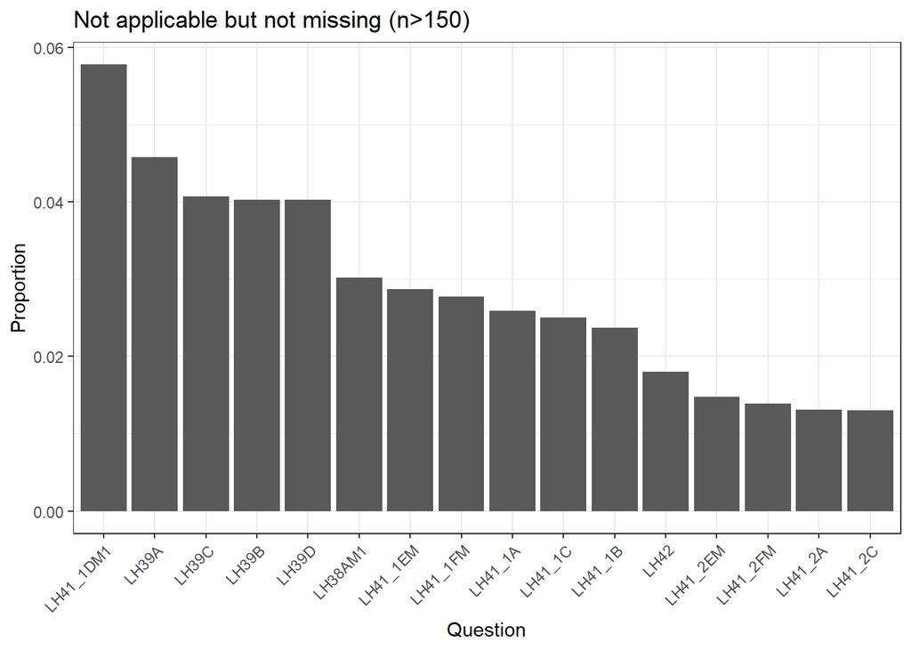

```r
am %>%
  filter(not_app_not_miss > 150) %>%
  arrange(desc(not_app_not_miss)) %>%
  mutate(questions = factor(x = questions, levels = questions)) %>%
  ggplot(data = .) +
  geom_bar(mapping = aes(x = questions, y = not_app_not_miss_rate), stat = "identity") +
  labs(x = "Question", y = "Proportion", title = "Not applicable but not missing (n>150)") +
  theme_bw()+
  theme(axis.text.x = element_text(angle=45,hjust=1))
```

The question with the largest proportion of not applicable but not missing is Q41_1DM, which is a select-all-that-apply question in a grid matrix. As we added a threshold of 2018 when coding this question, it can be caused due to this threshold that respondents did not pay too much attention on skip patterns of the questionnaire. Another question is Q39, which might also due to the skip patterns.

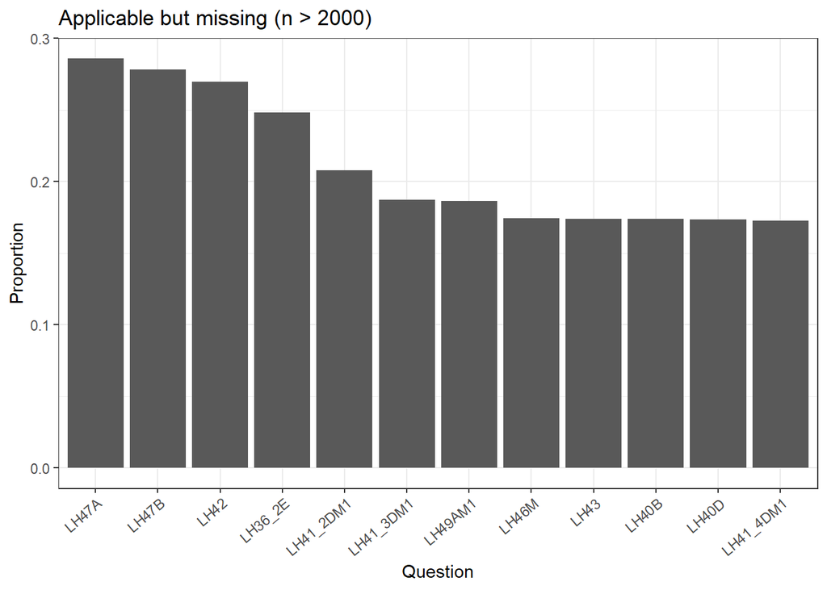

```r
am %>%
  filter(app_but_miss > 2000) %>%
  arrange(desc(app_but_miss)) %>%
  mutate(questions = factor(x = questions, levels = questions)) %>%
  ggplot(data = .) +
  geom_bar(mapping = aes(x = questions, y = app_but_miss_rate), stat = "identity") +
  labs(x = "Question", y = "Proportion", title = "Applicable but missing (n > 2000)") +
  theme_bw() +
  theme(axis.text.x = element_text(angle = 40, vjust = 1, hjust = 1))
```

The question with the most frequent missingness is Q47, which is a sensitive question. The missingness also happens quite often in Q42, which can be caused by the trend that respondents are skipping this question due to fatigue or less effort. Q36_2E also has relatively frequent missingness.